# 30535 Skills Problem Set 5

Hye-Min Jung

5/22/2020

This submission is my work alone and complies with the 30535 integrity policy. **Hye-Min Jung**  
Collaborators:  
Late coins used this pset: 3. Late coins left: 3.

I followed the style guide including the new points on styling joins.

# 1 R4DS Chapter 13 Joins part 2

1. Use facets to plot the spatial patterns of delays on “June 13 2013” along with a comparison plot of “normal” delays and then use Google to cross-reference with the weather. (Use the “question, query, result, answer” framework to answer this question. In addition to your written answer, make the plot title be a succinct answer.)

> Question : What happened on June 13 2013?

> Query

```r
library(viridis)
not_cancelled <- flights %>%
  filter(!is.na(dep_time), !is.na(arr_time), !is.na(dep_delay), !is.na(arr_delay)) %>%
  filter(dest != "HNL", dest != "ANC")
```

> Result

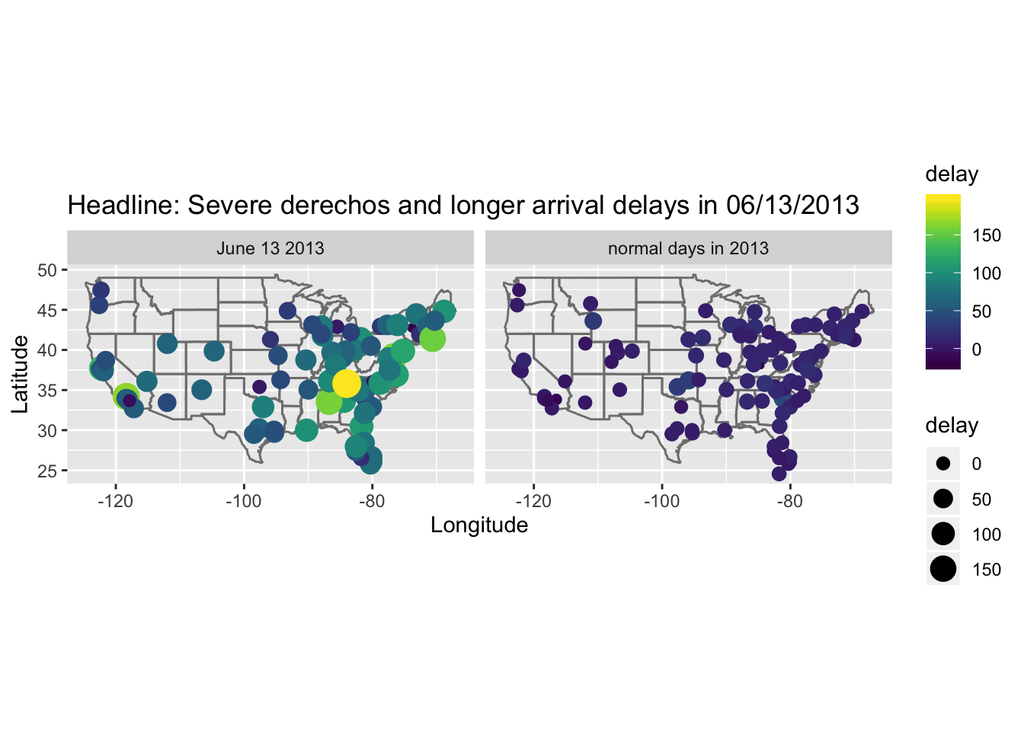

```r
not_cancelled %>%
  mutate(
    date = substr(time_hour, 1, 10),
    comparison = ifelse(date == "2013-06-13", "June 13 2013", "normal days in 2013")
  ) %>%
  group_by(dest, comparison) %>%
  summarise(delay = mean(arr_delay, na.rm = TRUE)) %>%
  inner_join(airports, by = c("dest" = "faa")) %>%
  ggplot(aes(x = lon, y = lat, size = delay, colour = delay)) +
  borders("state") +
  geom_point() +
  coord_quickmap() +
  scale_color_viridis() +
  labs(title = "Headline: Severe derechos and longer arrival delays in 06/13/2013", x = "Longitude", y = "Latitude") +
  facet_wrap(~comparison)
```

> Answer
- **Head_meassage**
  - Severe derechos and longer arrival delays in 06/13/2013.
- **Sub-messages**
  - 1. Due to 2 derechos occurred across different areas of the Eastern United States from 06/12~13 in 2013, delays were significantly longer in 06/13 than normal other days in 2013.
  - 2. Delays were more severe in east coast than west coast. This is consistent with path of June 12–13, 2013 Derecho Series that hit Midwest and Mid Atlantic.
  - 3. TYS, BUR, BWI were top 3 airports with longest average delays. (Affected the most)
  - 4. STT, SLB, GSO were top 3 airports with least average delays. (Affected the least)
  - resource: https://en.wikipedia.org/wiki/June_12–13,_2013_derecho_series
- **What does anti_join(flights, airports, by = c(“dest” = “faa”)) tell you?**
  - Output for running this code returns the flights that went to an airport that is not in the faa list as a destinations.
  - Here, we are connecting `flights` and `airplanes` by using`dest` and foreign key `faa` and `anti_join` is used to diagnose mismatches, by checking whether the foreign keys match primary keys.
  - So this code, let us know destination don’t have a match in `airports`.

```r
anti_join(flights, airports, by = c("dest" = "faa"))
```

```
## # A tibble: 7,602 x 19
##     year month   day dep_time sched_dep_time dep_delay arr_time
##    <int> <int> <int>    <int>          <int>     <dbl>    <int>
##  1  2013     1     1      544            545        -1     1004
##  2  2013     1     1      615            615         0     1039
##  3  2013     1     1      628            630        -2     1137
##  4  2013     1     1      701            700         1     1123
##  5  2013     1     1      711            715        -4     1151
##  6  2013     1     1      820            820         0     1254
##  7  2013     1     1      820            820         0     1249
##  8  2013     1     1      840            845        -5     1311
##  9  2013     1     1      909            810        59     1331
## 10  2013     1     1      913            918        -5     1346
## # … with 7,592 more rows, and 12 more variables: sched_arr_time <int>,
## #   arr_delay <dbl>, carrier <chr>, flight <int>, tailnum <chr>,
## #   origin <chr>, dest <chr>, air_time <dbl>, distance <dbl>, hour <dbl>,
## #   minute <dbl>, time_hour <dttm>
```

```r
flights %>%
  count(dest) %>%
  filter(n > 1)
```

```
## # A tibble: 103 x 2
##    dest      n
##    <chr> <int>
##  1 ABQ     254
##  2 ACK     265
##  3 ALB     439
##  4 ANC       8
##  5 ATL   17215
##  6 AUS    2439
##  7 AVL     275
##  8 BDL     443
##  9 BGR     375
## 10 BHM     297
## # … with 93 more rows
```

```r
airports %>%
  count(faa) %>%
  filter(n > 1)
```

```
## # A tibble: 0 x 2
## # … with 2 variables: faa <chr>, n <int>
```

- **What does anti_join(airports, flights, by = c(“faa” = “dest”)) tell you?**
  - Output for running this code returns the US airports that were not the destinations of any flight from New York City airports in 2013.

```r
anti_join(airports, flights, by = c("faa" = "dest"))
```

```
## # A tibble: 1,357 x 8
##    faa   name                    lat    lon   alt    tz dst   tzone
##    <chr> <chr>                 <dbl>  <dbl> <dbl> <dbl> <chr> <chr>
##  1 04G   Lansdowne Airport      41.1  -80.6  1044    -5 A     America/New_…
##  2 06A   Moton Field Municipa…  32.5  -85.7   264    -6 A     America/Chic…
##  3 06C   Schaumburg Regional    42.0  -88.1   801    -6 A     America/Chic…
##  4 06N   Randall Airport        41.4  -74.4   523    -5 A     America/New_…
##  5 09J   Jekyll Island Airport  31.1  -81.4    11    -5 A     America/New_…
##  6 0A9   Elizabethton Municip…  36.4  -82.2  1593    -5 A     America/New_…
##  7 0G6   Williams County Airp…  41.5  -84.5   730    -5 A     America/New_…
##  8 0G7   Finger Lakes Regiona…  42.9  -76.8   492    -5 A     America/New_…
##  9 0P2   Shoestring Aviation …  39.8  -76.6  1000    -5 U     America/New_…
## 10 0S9   Jefferson County Intl  48.1 -123.    108    -8 A     America/Los_…
## # … with 1,347 more rows
```

# 2 R4DS Chapter 14 stringr

1. **Use str_length() and str_sub() to extract the middle character (or characters for even lengthed words) from a string.**

```r
x <- c("Apple", "Banana", "Pear")
str_length(x)
```

```
## [1] 5 6 4
```

```r
str_sub(string = x, start = (str_length(x) + 1) / 2, end = (str_length(x) + 2) / 2)
```

```
## [1] "p"  "na" "ea"
```

2. **Write a regular expression to match “Gan” where “” can include any character or no character at all. Prove your regular expression works with three examples.**

```r
y <- c("Gan", "Gana", "Gandalfhello")
str_view(y, "Gan\\w*")
```

[interactive chart not shown]

3. Given the corpus of common words in stringr::words, create regular expressions that find all words that:
- **1. Ends with “y”.**

```r
sum(str_detect(words, "y$"))
```

```
## [1] 84
```

- **2. Starts with “q”**

```r
sum(str_detect(words, "^q"))
```

```
## [1] 7
```

- **3. Are exactly four letters long. (Don’t use str_length()!)**

```r
sum(str_detect(words, "^....$"))
```

```
## [1] 263
```

- **4. Are 8 letters or longer.**

```r
sum(str_detect(words, "........"))
```

```
## [1] 100
```

4. Create regular expressions to find all words in stringr::words that meet the following criteria. In addition, please provide two test cases where your regular expression returns a match and two test cases that do not return a match.
- **1. Start with a vowel.**

```r
# regular expression returns a match
sum(str_detect(words, "^[aeiou]"))
```

```
## [1] 175
```

```r
## str_subset(words, "^[aeiou]") I did not run the code but it gave the same answer

# two test cases that do not return a match
sum(str_detect(words, "[aeiou]$"))
```

```
## [1] 271
```

```r
sum(str_detect(words, "[aeiou]"))
```

```
## [1] 974
```

- **2. That only contain consonants. (Hint: thinking about matching “not”-vowels.)**

```r
# regular expression returns a match
sum(str_detect(words, "^[^aeiou]+$"))
```

```
## [1] 6
```

```r
## str_subset(stringr::words, "^[^aeiou]+$") I did not run the code but it gave the same answer

# two test cases that do not return a match
sum(str_detect(words, "^[^aeiou]$"))
```

```
## [1] 0
```

```r
sum(str_detect(words, "[^aeiou]$"))
```

```
## [1] 709
```

- **3. End with ed, but not with eed.**

```r
# regular expression returns a match
sum(str_detect(words, pattern = "[^e]ed$"))
```

```
## [1] 3
```

```r
## str_subset(stringr::words, "[^e]ed$") I did not run the code but it gave the same answer

# two test cases that do not return a match
sum(str_detect(words, pattern = "[^e]ed"))
```

```
## [1] 5
```

```r
sum(str_detect(words, pattern = "[e]ed$"))
```

```
## [1] 6
```

- **4. End with ing or ise.**

```r
# regular expression returns a match
sum(str_detect(words, pattern = "ing$|ise$"))
```

```
## [1] 17
```

```r
## str_subset(stringr::words, "i(ng|se)$") I did not run the code but it gave the same answer

# two test cases that do not return a match
sum(str_detect(words, pattern = "ing|ise$"))
```

```
## [1] 18
```

```r
sum(str_detect(words, pattern = "ing|ise"))
```

```
## [1] 18
```

5. Show how telephone numbers are written in your country with three examples.
- **Create a regular expression that will match telephone numbers as commonly written in your country.**

```r
z <- c("010-2345-3535", "01023453535", "010.2345.3535")
str_view(z, "\\d\\d\\d-\\d\\d\\d\\d-\\d\\d\\d\\d")
```

[interactive chart not shown]

6. **Split up the string “apples, pears, and bananas” into individual components.**

```r
y <- c("apples, pears, and bananas")

str_split(y, " ")
```

```
## [[1]]
## [1] "apples," "pears,"  "and"     "bananas"
```

# 3 R4DS Chapter 15 for_cats

1. forcats::gss_cat includes data from the General Social Survey.
- **Explore the distribution of rincome (reported income).**

```r
gss_cat %>%
  count(rincome) %>%
  mutate(share = round(n / sum(n), 2))
```

```
## # A tibble: 16 x 3
##    rincome            n share
##    <fct>          <int> <dbl>
##  1 No answer        183  0.01
##  2 Don't know       267  0.01
##  3 Refused          975  0.05
##  4 $25000 or more  7363  0.34
##  5 $20000 - 24999  1283  0.06
##  6 $15000 - 19999  1048  0.05
##  7 $10000 - 14999  1168  0.05
##  8 $8000 to 9999    340  0.02
##  9 $7000 to 7999    188  0.01
## 10 $6000 to 6999    215  0.01
## 11 $5000 to 5999    227  0.01
## 12 $4000 to 4999    226  0.01
## 13 $3000 to 3999    276  0.01
## 14 $1000 to 2999    395  0.02
## 15 Lt $1000         286  0.01
## 16 Not applicable  7043  0.33
```

- **Make a bar chart with the distribution of rincome.**

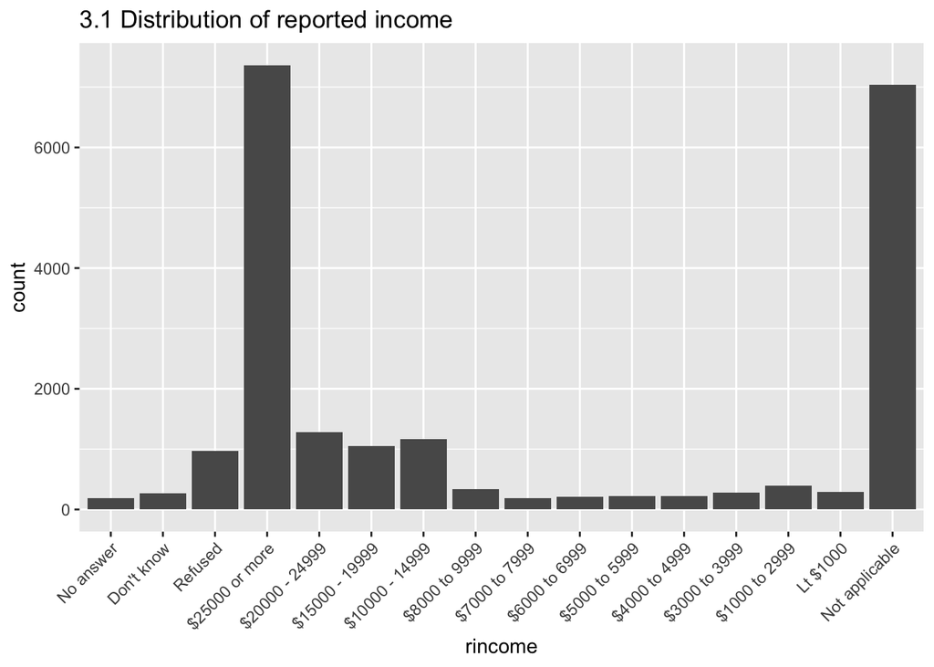

```r
ggplot(gss_cat, aes(rincome)) +
  geom_bar() +
  theme(axis.text.x = element_text(angle = 45, hjust = 1)) +
  labs(title = "3.1 Distribution of reported income")
```

- **What makes the default barchart hard to understand? Improve the chart.**
  - Default barchart has x-axis labeling overwrapping each other, because the texts are quite long.
  - I would `coord_flip()` to make it horizontal.

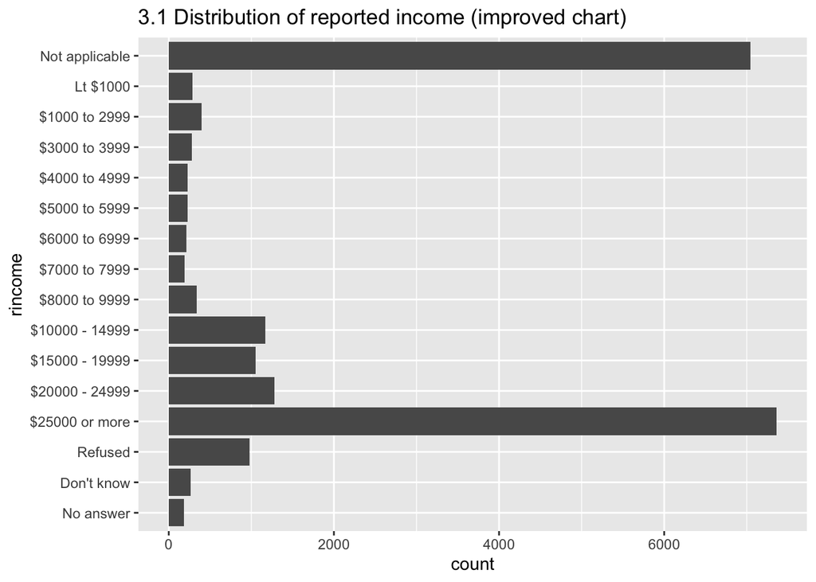

```r
ggplot(gss_cat, aes(rincome)) +
  geom_bar() +
  scale_x_discrete(drop = FALSE) +
  labs(title = "3.1 Distribution of reported income (improved chart)") +
  coord_flip()
```

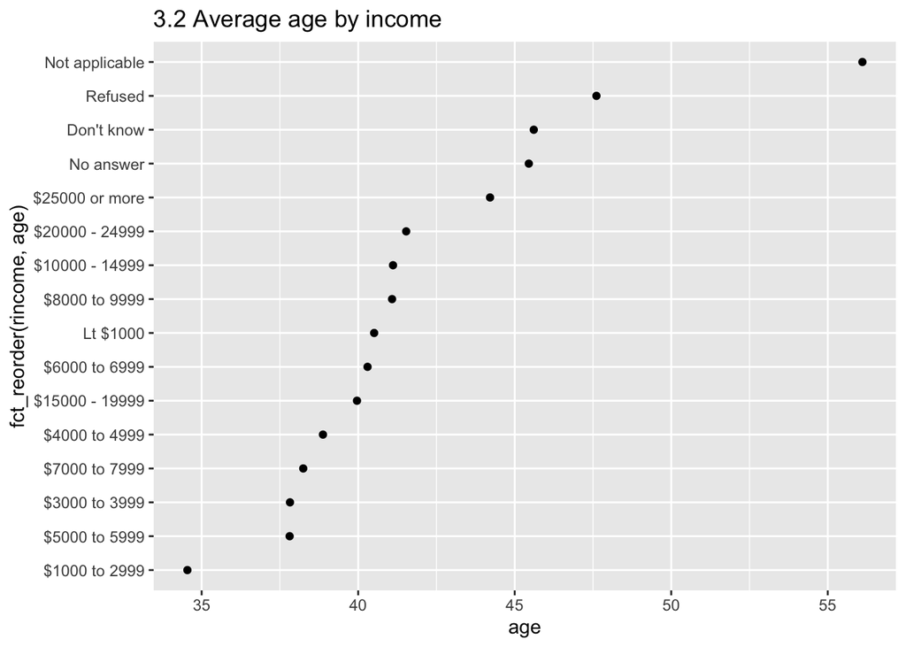

```r
rincome_summary <- gss_cat %>%
  group_by(rincome) %>%
  summarise(
    age = mean(age, na.rm = TRUE),
    tvhours = mean(tvhours, na.rm = TRUE),
    n = n()
  )

ggplot(rincome_summary, aes(age, fct_reorder(rincome, age))) +
  geom_point() +
  labs(title = "3.2 Average age by income")
```

3. There are some suspiciously high numbers in tvhours.
1. Make a plot to examine the variable’s distribution.
- **What number do you consider to be unreasonably high?**
  - 24 is unreasonably high, considering that the tvhours are hours ‘per day watching tv’.

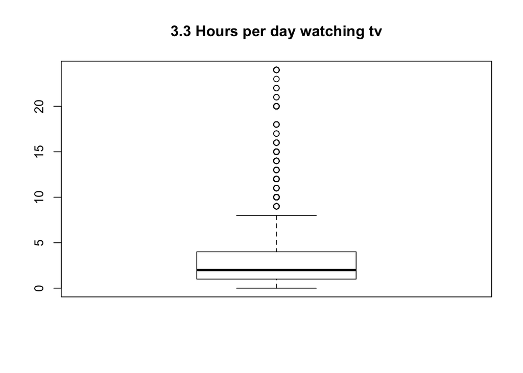

```r
boxplot(gss_cat$tvhours, main = "3.3 Hours per day watching tv")
```

```r
max(gss_cat$tvhours, na.rm = TRUE)
```

```
## [1] 24
```

2. Review the three options for handling outliers from lecture 3.
- **What is your preferred option and why?**
  - I would like to winsorize, because I don’t know whether data is correct.
  - If I know that the data is incorrect, I could re-code outliers to NAs or just drop them.
  - But, because I don’t want outliers to drive all the results, without knowing how they were collected nor I can talk to the data provider, I would rather choose to winsorize them.
- **Implement this in your code and remake the “how much TV do people watch by religion?” plot from lecture using the revised data.**

```r
library(statar)
gss_cat_clean <-
  gss_cat %>%
  mutate(tvhour_winsor = winsorize(tvhours, probs = c(0.01, 0.99)))
```

```
## 0.00 % observations replaced at the bottom
```

```
## 0.51 % observations replaced at the top
```

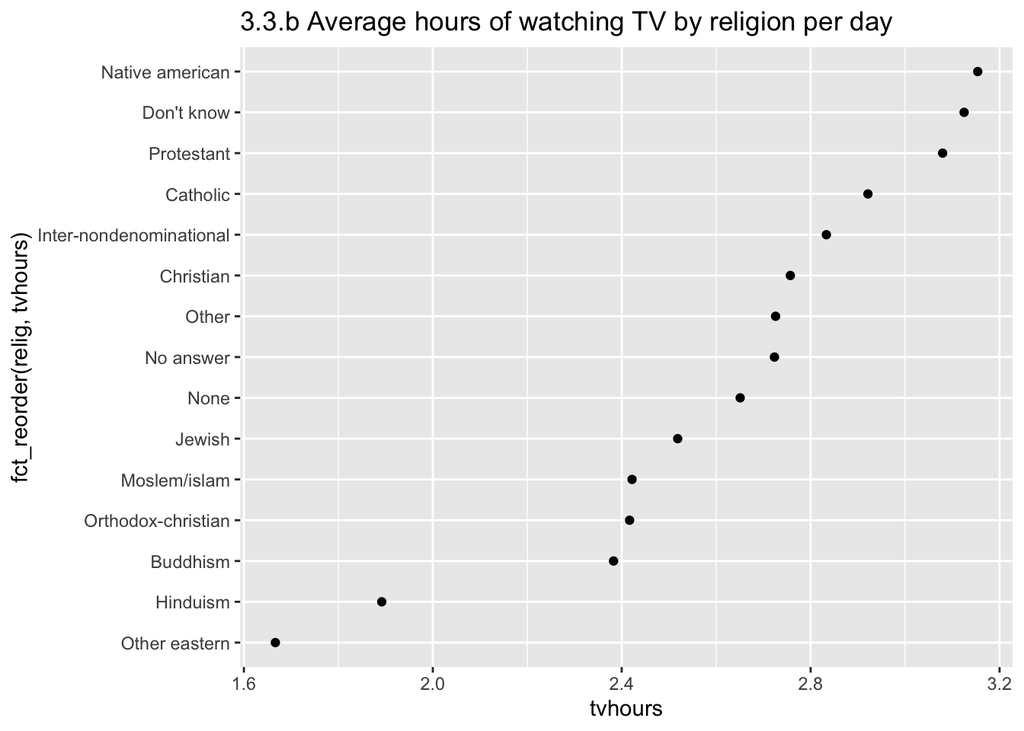

```r
relig_summary_reorder <-
  gss_cat_clean %>%
  group_by(relig) %>%
  summarise(
    age = mean(age, na.rm = TRUE),
    tvhours = mean(tvhour_winsor, na.rm = TRUE),
    n = n(),
    se = sd(tvhour_winsor, na.rm = TRUE) / sqrt(n),
    lower_bound = tvhours - 1.645 * se,
    upper_bound = tvhours + 1.645 * se
  )

ggplot(relig_summary_reorder, aes(tvhours, fct_reorder(relig, tvhours))) +
  geom_point() +
  labs(title = "3.3.b Average hours of watching TV by religion per day")
```

3. Add 90 percent confidence intervals using geom_linerange(). Calculate standard errors $\frac{\hat{\sigma}}{\sqrt{n}}$ where $\hat{\sigma}$ is the standard deviation for each group and n is the number of observation within a group. Comment on how this changes your understanding of the plot.

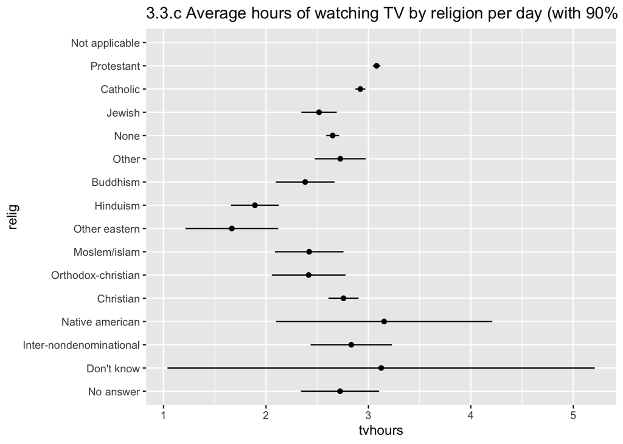

```r
ggplot(relig_summary_reorder) +
  geom_point(aes(x = relig, y = tvhours)) +
  labs(title = "3.3.c Average hours of watching TV by religion per day (with 90% C.I)") +
  geom_linerange(aes(x = relig, y = tvhours, ymin = lower_bound, ymax = upper_bound)) +
  scale_x_discrete(drop = FALSE) +
  coord_flip()
```

4. **Why does moving “Not applicable” to the front of the levels move it to the bottom of the plot?**
- That gives the level “Not applicable” an integer value of 1.
- So when you pulling “Not applicable” to the front with th other special levels, it takes a factor, `f`, and then any number of levels that you want to move to the front of the line.

# 4 R4DS Chapter 16: lubridate

```r
not_cancelled <- flights %>%
  filter(!is.na(dep_time), !is.na(arr_time))

(all_delayed_cases <-
  not_cancelled %>%
  mutate(
    dep_time_new = sub("(\\d+)(\\d{2})", "\\1:\\2", dep_time),
    sched_dep_time_new = sub("(\\d+)(\\d{2})", "\\1:\\2", sched_dep_time),
    subtract = strptime(dep_time_new, format = "%H:%M") - strptime(sched_dep_time_new, format = "%H:%M"),
    dep_delay_in_sec = dep_delay * 60,
    dep_delay_new = as.duration(dep_delay_in_sec),
    diff = dep_delay_new - subtract
  ) %>%
  select(dep_time_new, sched_dep_time_new, dep_delay_new, subtract, diff))
```

```
## # A tibble: 328,063 x 5
##    dep_time_new sched_dep_time_new dep_delay_new     subtract  diff
##    <chr>        <chr>              <Duration>        <drtn>    <Duration>
##  1 5:17         5:15               120s (~2 minutes)  120 secs 0s
##  2 5:33         5:29               240s (~4 minutes)  240 secs 0s
##  3 5:42         5:40               120s (~2 minutes)  120 secs 0s
##  4 5:44         5:45               60s (~1 minutes)   -60 secs 0s
##  5 5:54         6:00               360s (~6 minutes) -360 secs 0s
##  6 5:54         5:58               240s (~4 minutes) -240 secs 0s
##  7 5:55         6:00               300s (~5 minutes) -300 secs 0s
##  8 5:57         6:00               180s (~3 minutes) -180 secs 0s
##  9 5:57         6:00               180s (~3 minutes) -180 secs 0s
## 10 5:58         6:00               120s (~2 minutes) -120 secs 0s
## # … with 328,053 more rows
```

```r
(equation_does_hold <-
  all_delayed_cases %>%
  filter(diff == as.duration(0)))
```

```
## # A tibble: 326,858 x 5
##    dep_time_new sched_dep_time_new dep_delay_new     subtract  diff
##    <chr>        <chr>              <Duration>        <drtn>    <Duration>
##  1 5:17         5:15               120s (~2 minutes)  120 secs 0s
##  2 5:33         5:29               240s (~4 minutes)  240 secs 0s
##  3 5:42         5:40               120s (~2 minutes)  120 secs 0s
##  4 5:44         5:45               60s (~1 minutes)   -60 secs 0s
##  5 5:54         6:00               360s (~6 minutes) -360 secs 0s
##  6 5:54         5:58               240s (~4 minutes) -240 secs 0s
##  7 5:55         6:00               300s (~5 minutes) -300 secs 0s
##  8 5:57         6:00               180s (~3 minutes) -180 secs 0s
##  9 5:57         6:00               180s (~3 minutes) -180 secs 0s
## 10 5:58         6:00               120s (~2 minutes) -120 secs 0s
## # … with 326,848 more rows
```

```r
(equation_does_not_hold <-
  all_delayed_cases %>%
  filter(diff > as.duration(0)))
```

```
## # A tibble: 324 x 5
##    dep_time_new sched_dep_time_… dep_delay_new         subtract
##    <chr>        <chr>            <Duration>            <drtn>
##  1 8:48         18:35            51180s (~14.22 hours) -35220 …
##  2 1:26         22:50            9360s (~2.6 hours)    -77040 …
##  3 2:35         23:59            9360s (~2.6 hours)    -77040 …
##  4 1:06         22:45            8460s (~2.35 hours)   -77940 …
##  5 6:41         9:00             78060s (~21.68 hours)  -8340 …
##  6 11:21        16:35            67560s (~18.77 hours) -18840 …
##  7 1:08         22:45            8580s (~2.38 hours)   -77820 …
##  8 1:15         20:00            18900s (~5.25 hours)  -67500 …
##  9 1:58         21:59            14340s (~3.98 hours)  -72060 …
## 10 1:23         20:00            19380s (~5.38 hours)  -67020 …
## # … with 314 more rows, and 1 more variable: diff <Duration>
```

- resource: https://stackoverflow.com/questions/43509559/i-want-to-convert-a-number-to-time-in-r
2. **Use the appropriate lubridate function to parse each of the following dates:**

```r
d1 <- "1213-Apr-03"
ymd(d1)
```

```
## [1] "1213-04-03"
```

```r
d2 <- "06-Jun-2017"
dmy(d2)
```

```
## [1] "2017-06-06"
```

```r
d3 <- "12/29/14" # Dec 29, 2014
mdy(d3)
```

```
## [1] "2014-12-29"
```

```r
d4 <- "November 20, 1909"
mdy(d4)
```

```
## [1] "1909-11-20"
```

```r
d5 <- c("January 2 (2016)", "January 2 (2018)")

mdy(d5)
```

```
## [1] "2016-01-02" "2018-01-02"
```

3. **Make a plot with four lines: For each season, show the distribution of flight times within a day.**

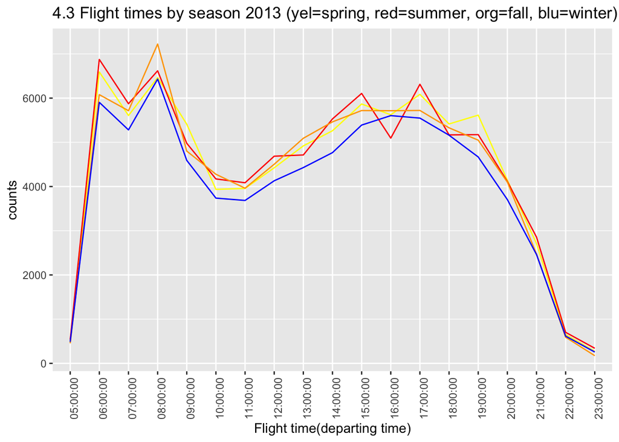

```r
not_cancelled <- flights %>%
  filter(!is.na(dep_time), !is.na(arr_time), !is.na(dep_delay), !is.na(arr_delay)) %>%
  filter(dest != "HNL", dest != "ANC") %>%
  mutate(
    season =
      ifelse(month %in% c(12, 1, 2), "winter",
        ifelse(month %in% c(3, 4, 5), "spring",
          ifelse(month %in% c(6, 7, 8), "summer", "fall")
        )
      )
  ) %>%
  mutate(
    flight_time = format(time_hour, "%H:%M:%S"),
    date = substr(time_hour, 1, 10),
    weekday = weekdays(as.Date(date))
  )

spring <- not_cancelled %>%
  filter(season == "spring") %>%
  group_by(flight_time) %>%
  count()

summer <- not_cancelled %>%
  filter(season == "summer") %>%
  group_by(flight_time) %>%
  count()

fall <- not_cancelled %>%
  filter(season == "fall") %>%
  group_by(flight_time) %>%
  count()

winter <- not_cancelled %>%
  filter(season == "winter") %>%
  group_by(flight_time) %>%
  count()

ggplot() +
  geom_line(data = spring, aes(x = flight_time, y = n), color = "yellow", group = 1) +
  geom_line(data = summer, aes(x = flight_time, y = n), color = "red", group = 1) +
  geom_line(data = fall, aes(x = flight_time, y = n), color = "orange", group = 1) +
  geom_line(data = winter, aes(x = flight_time, y = n), color = "blue", group = 1) +
  theme(axis.text.x = element_text(angle = 90, hjust = 1)) +
  labs(title = "4.3 Flight times by season 2013 (yel=spring, red=summer, org=fall, blu=winter)", x = "Flight time(departing time)", y = "counts")
```

- **How does the distribution change?**
  - The number of flights are highest between 6~8am and decrease in the number of flights.
  - Then the number of flights increase until 16~17 then decrease until the midnight.
- **Which day of the week has the smallest probability of an arrival delay?**
  - Saturday has smallest probability of an arrival delay.
  - Probability of an arrival delay is estimated by calculating the mean of arrival delays by weekdays.

```r
not_cancelled %>%
  group_by(weekday) %>%
  summarise(ave_delay = mean(arr_delay, na.rm = TRUE)) %>%
  arrange(ave_delay)
```

```
## # A tibble: 7 x 2
##   weekday   ave_delay
##   <chr>         <dbl>
## 1 Saturday      -1.44
## 2 Sunday         4.84
## 3 Tuesday        5.39
## 4 Wednesday      7.04
## 5 Friday         9.10
## 6 Monday         9.68
## 7 Thursday      11.8
```

- **Does this change if we only consider long delays?**
  - Yes, tuesday is has smallest probabilty of an arrival delay, if we only consider long delays.
  - I’ve filtered 0.99 percentile of arrival delay which is higher or equal than 190.
  - Then the result changed.

```r
not_cancelled %>% summarise(quantile(arr_delay, probs = 0.99))
```

```
## # A tibble: 1 x 1
##   `quantile(arr_delay, probs = 0.99)`
##                                 <dbl>
## 1                                 190
```

```r
not_cancelled %>%
  filter(arr_delay >= 190) %>%
  group_by(weekday) %>%
  summarise(ave_delay = mean(arr_delay, na.rm = TRUE)) %>%
  arrange(ave_delay)
```

```
## # A tibble: 7 x 2
##   weekday   ave_delay
##   <chr>         <dbl>
## 1 Tuesday        248.
## 2 Monday         255.
## 3 Friday         257.
## 4 Wednesday      260.
## 5 Sunday         263.
## 6 Thursday       264.
## 7 Saturday       268.
```

- **Make a plot using facets to show both plots.**

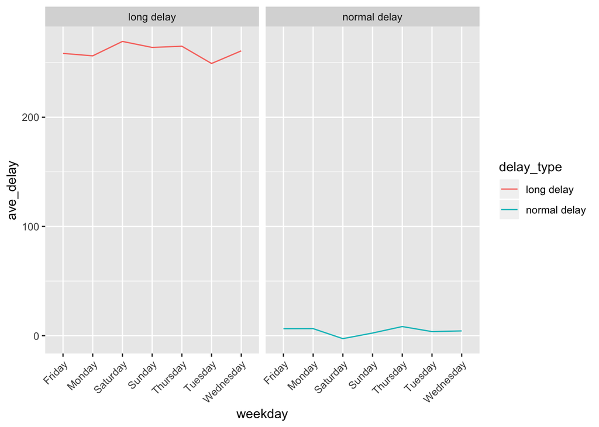

```r
not_cancelled %>%
  mutate(delay_type = ifelse(arr_delay > 190, "long delay", "normal delay")) %>%
  group_by(weekday, delay_type) %>%
  summarise(ave_delay = mean(arr_delay, na.rm = TRUE)) %>%
  ggplot(aes(x = weekday, y = ave_delay, color = delay_type, group = delay_type)) +
  geom_line() +
  facet_wrap(~delay_type) +
  theme(axis.text.x = element_text(angle = 45, hjust = 1))
```

- **Create a vector of dates giving the seventh day of every month in 2012.**

```r
ymd(20111207) + months(1:12)
```

```
##  [1] "2012-01-07" "2012-02-07" "2012-03-07" "2012-04-07" "2012-05-07"
##  [6] "2012-06-07" "2012-07-07" "2012-08-07" "2012-09-07" "2012-10-07"
## [11] "2012-11-07" "2012-12-07"
```

- **Create a vector of dates giving the fifth day of every month in 2020.**

```r
ymd(20191205) + months(1:12)
```

```
##  [1] "2020-01-05" "2020-02-05" "2020-03-05" "2020-04-05" "2020-05-05"
##  [6] "2020-06-05" "2020-07-05" "2020-08-05" "2020-09-05" "2020-10-05"
## [11] "2020-11-05" "2020-12-05"
```

6. **Write a function that given your birthday (as a date), returns how old you are in years.**

```r
as.duration(today() - ymd(19910305))
```

```
## [1] "922233600s (~29.22 years)"
```

7. If your home country is not the US, find the locale object for your home country and print it in your problem set. **Print a date object which includes the day of the week, month, calendar day and year and uses the home country locale.**

```r
library(readr)
parse_date("31 DICIEMBRE 2011", "%d %B %Y", locale = locale("es"))
```

```
## [1] "2011-12-31"
```

- I am Korea, but I’ve tried same with locale(“ko”), it keep gives me error.
- So I pretend, that I am spanish and print a date object.